# Testing affect regulation via computational modeling of real-time alcohol choices in daily life — Sensitivity Analyses: Boundary Separation (B)

### 4.3.4 Predicted vs. Observed

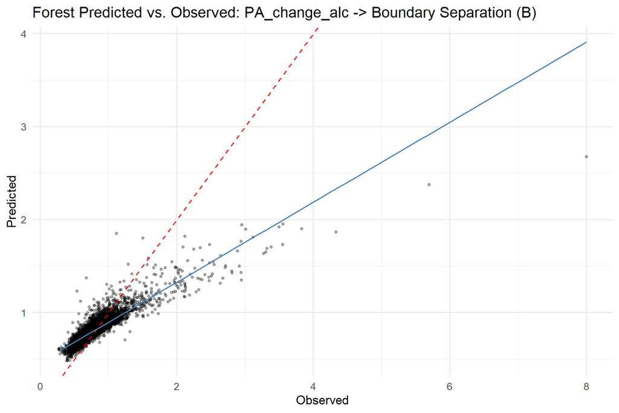

## 4.4 Model Comparison

### 4.4.1 RMSE Comparison (all methods and feature sets)

| Method | Raw | PCA | UMAP |
| --- | --- | --- | --- |
| glmm | 0.3173 | 0.3172 | 0.3173 |
| forest | 0.2902 | 0.3091 | 0.2995 |
| tree | 0.3184 | 0.3183 | 0.3184 |

# 5 Perceived Stress Change (vs. last assessment) (stress_state_change)

## 5.1 Dimensionality Reduction

- **PCA components (80% variance, max 5):** 5
- **UMAP components (matching PCA):** 5

### 5.1.1 PCA Component Composition (top 5 correlated variables)

**PC_1**

| Variable | Correlation |
| --- | --- |
| alc_exp_energeticYes | -0.576 |
| alc_exp_better_moodYes | -0.557 |
| alc_exp_sociableYes | -0.547 |
| alc_exp_buzzYes | -0.502 |
| alc_craving | -0.487 |

**PC_2**

| Variable | Correlation |
| --- | --- |
| alc_exp_injuryYes | -0.596 |
| alc_exp_be_rudeYes | -0.594 |
| alc_exp_embarrassedYes | -0.579 |
| alc_exp_nauseous_vomitYes | -0.491 |
| alc_exp_hangoverYes | -0.468 |

**PC_3**

| Variable | Correlation |
| --- | --- |
| locationschool_work | 0.591 |
| alc_today | -0.579 |
| alc_cuenone | 0.569 |
| time_of_dayevening | -0.476 |
| locationhome | -0.458 |

**PC_4**

| Variable | Correlation |
| --- | --- |
| soft_yday | 0.699 |
| soft_today | 0.651 |
| soft_intend | 0.635 |
| soft_craving | 0.489 |
| alc_exp_embarrassedYes | -0.388 |

**PC_5**

| Variable | Correlation |
| --- | --- |
| locationhome | -0.633 |
| social_context_aloneYes | -0.559 |
| social_context_friend_roommateYes | 0.500 |
| social_context_strangerYes | 0.418 |
| locationsomeone_elses_home | 0.371 |

### 5.1.2 UMAP Component Composition (top 5 correlated variables)

**UMAP_1**

| Variable | Correlation |
| --- | --- |
| alc_exp_embarrassedYes | -0.328 |
| alc_exp_be_rudeYes | -0.325 |
| alc_craving | -0.282 |
| alc_intend | -0.196 |
| soft_today | -0.191 |

**UMAP_2**

| Variable | Correlation |
| --- | --- |
| alc_yday | 0.397 |
| alc_intend | 0.197 |
| alc_mot_enhanceYes | 0.130 |
| alc_cuenone | -0.104 |
| alc_exp_hangoverYes | 0.087 |

**UMAP_3**

| Variable | Correlation |
| --- | --- |
| alc_yday | -0.354 |
| alc_today | -0.340 |
| soft_craving | 0.178 |
| thirst_state | 0.166 |
| hunger_state | 0.145 |

**UMAP_4**

| Variable | Correlation |
| --- | --- |
| soft_yday | 0.780 |
| soft_today | 0.663 |
| soft_intend | 0.557 |
| soft_craving | 0.291 |
| alc_exp_injuryYes | 0.167 |

**UMAP_5**

| Variable | Correlation |
| --- | --- |
| alc_exp_injuryYes | 0.499 |
| alc_exp_embarrassedYes | 0.357 |
| alc_exp_be_rudeYes | 0.354 |
| alc_exp_nauseous_vomitYes | 0.350 |
| alc_exp_energeticYes | 0.210 |

## 5.2 GLMM Results

### 5.2.1 Raw Features

- **Optimal lambda:** 200 (index 1 of 21)
- **CV RMSE:** 0.3192

**Non-zero coefficients** (focal predictor terms highlighted):

| Term | Estimate | Category |
| --- | --- | --- |
| (Intercept) | 0.8117 | Intercept |
| stress_state_change | -0.0077 | Focal predictor |
| time_of_dayevening:stress_state_change | 0.0813 | Interaction with focal predictor |
| locationhome:stress_state_change | -0.0094 | Interaction with focal predictor |
| alc_exp_relaxedYes:stress_state_change | -0.0047 | Interaction with focal predictor |
| alc_mot_enhanceYes:stress_state_change | -0.0043 | Interaction with focal predictor |
| responsibilityYes:stress_state_change | -0.0039 | Interaction with focal predictor |
| social_context_aloneYes:stress_state_change | -0.0037 | Interaction with focal predictor |
| alc_mot_copingYes:stress_state_change | -0.0030 | Interaction with focal predictor |
| alc_cuenone:stress_state_change | -0.0029 | Interaction with focal predictor |
| tired_state:stress_state_change | -0.0026 | Interaction with focal predictor |
| alc_exp_buzzYes:stress_state_change | -0.0022 | Interaction with focal predictor |
| alc_today:stress_state_change | -0.0021 | Interaction with focal predictor |
| alc_exp_better_moodYes:stress_state_change | -0.0020 | Interaction with focal predictor |
| alc_craving:stress_state_change | -0.0017 | Interaction with focal predictor |
| soft_today:stress_state_change | -0.0014 | Interaction with focal predictor |
| alc_yday:stress_state_change | -0.0005 | Interaction with focal predictor |
| thirst_state:stress_state_change | -0.0004 | Interaction with focal predictor |
| soft_yday:stress_state_change | -0.0003 | Interaction with focal predictor |
| alc_intend:stress_state_change | 0.0002 | Interaction with focal predictor |
| hunger_state:stress_state_change | 0.0002 | Interaction with focal predictor |
| soft_craving:stress_state_change | 0.0002 | Interaction with focal predictor |
| social_context_romantic_partnerYes:stress_state_change | 0.0002 | Interaction with focal predictor |

- 75 coefficients penalized to zero.*

#### 5.2.1.1 Predicted vs. Observed

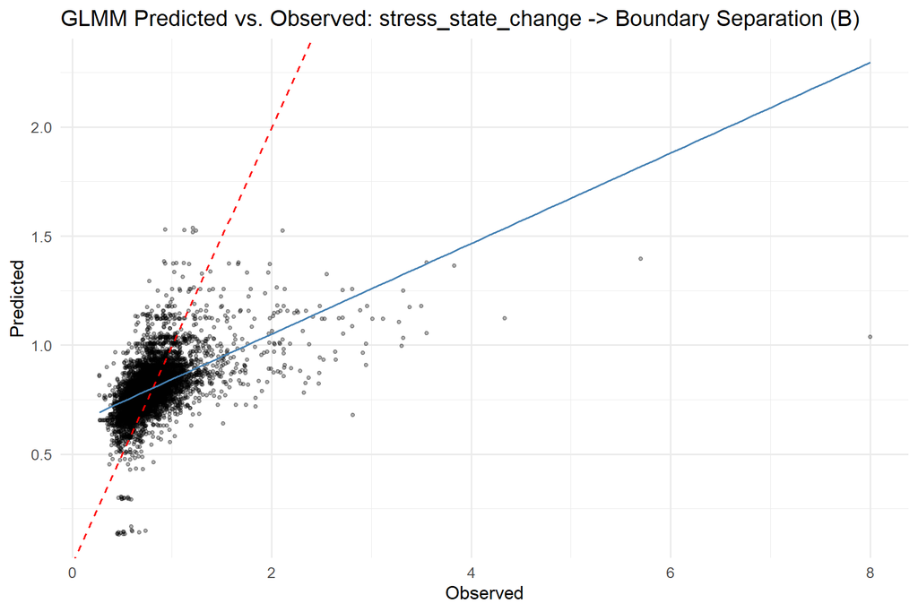

#### 5.2.1.2 Residual Diagnostics

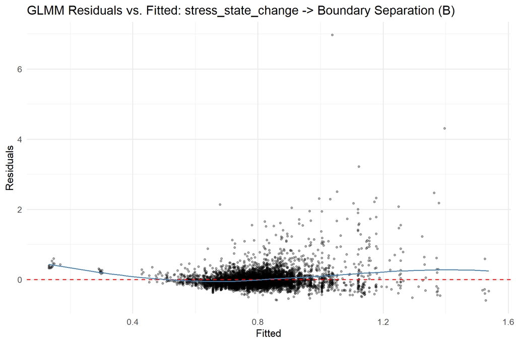

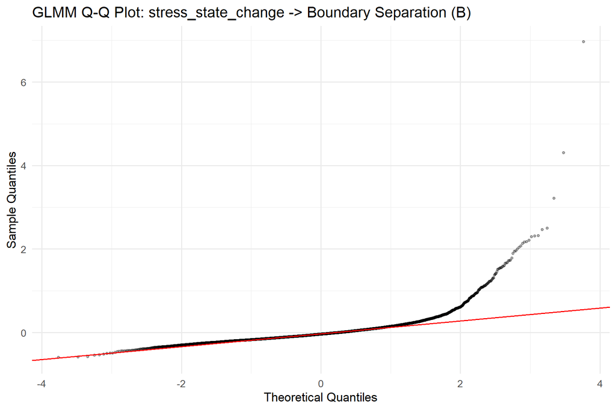

### 5.2.2 PCA Features

- **Optimal lambda:** 150 (index 6 of 21)
- **CV RMSE:** 0.3192

**Non-zero coefficients:**

| Term | Estimate |
| --- | --- |
| (Intercept) | 0.8074 |
| PC_5:stress_state_change | 0.0055 |

- 10 coefficients penalized to zero.*

### 5.2.3 UMAP Features

- **Optimal lambda:** 60 (index 15 of 21)
- **CV RMSE:** 0.3193

**Non-zero coefficients:**

| Term | Estimate |
| --- | --- |
| (Intercept) | 0.8069 |
| UMAP_1 | -0.0103 |
| UMAP_5:stress_state_change | 0.0061 |

- 9 coefficients penalized to zero.*

## 5.3 Random Forest Results (Raw)

### 5.3.1 Tuning Summary

- **mtry:** 14
- **min.node.size:** 3
- **sample.fraction:** 0.731
- **CV RMSE:** 0.2926

### 5.3.2 Variable Importance (Permutation)

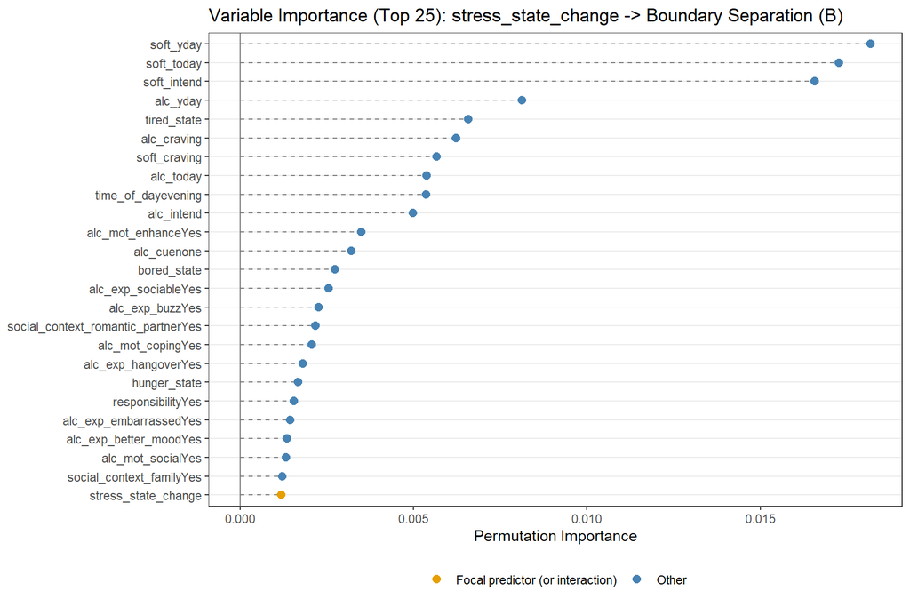

**Full importance ranking:**

| Variable | Importance |
| --- | --- |
| soft_yday | 0.018182 |
| soft_today | 0.017274 |
| soft_intend | 0.016566 |
| alc_yday | 0.008121 |
| tired_state | 0.006571 |
| alc_craving | 0.006232 |
| soft_craving | 0.005658 |
| alc_today | 0.005373 |
| time_of_dayevening | 0.005363 |
| alc_intend | 0.004974 |
| alc_mot_enhanceYes | 0.003491 |
| alc_cuenone | 0.003203 |
| bored_state | 0.002731 |
| alc_exp_sociableYes | 0.002550 |
| alc_exp_buzzYes | 0.002259 |
| social_context_romantic_partnerYes | 0.002167 |
| alc_mot_copingYes | 0.002070 |
| alc_exp_hangoverYes | 0.001806 |
| hunger_state | 0.001676 |
| responsibilityYes | 0.001548 |
| alc_exp_embarrassedYes | 0.001434 |
| alc_exp_better_moodYes | 0.001350 |
| alc_mot_socialYes | 0.001327 |
| social_context_familyYes | 0.001217 |
| stress_state_change | 0.001190 |
| alc_exp_energeticYes | 0.001148 |
| locationhome | 0.001095 |
| alc_exp_be_rudeYes | 0.000906 |
| social_context_aloneYes | 0.000886 |
| thirst_state | 0.000866 |
| locationschool_work | 0.000530 |
| alc_exp_nauseous_vomitYes | 0.000361 |
| social_context_friend_roommateYes | 0.000160 |
| social_context_coworker_classmateYes | 0.000072 |
| alc_exp_injuryYes | 0.000064 |
| day_of_weekMon | 0.000043 |
| alc_cueindirectly_visible | 0.000041 |
| social_context_strangerYes | 0.000038 |
| locationoutdoors | 0.000023 |
| locationsomeone_elses_home | 0.000016 |
| social_context_otherYes | 0.000003 |
| locationrestaurant_cafe | -0.000005 |
| day_of_weekThu | -0.000009 |
| locationother | -0.000069 |
| day_of_weekTue | -0.000159 |
| alc_exp_relaxedYes | -0.000197 |
| day_of_weekSun | -0.000338 |
| day_of_weekWed | -0.000422 |
| day_of_weekSat | -0.001071 |

### 5.3.3 Partial Dependence Plots

PDP for the focal predictor and the top 5 most important non-interaction covariates.

#### 5.3.3.1 Focal Predictor: stress_state_change

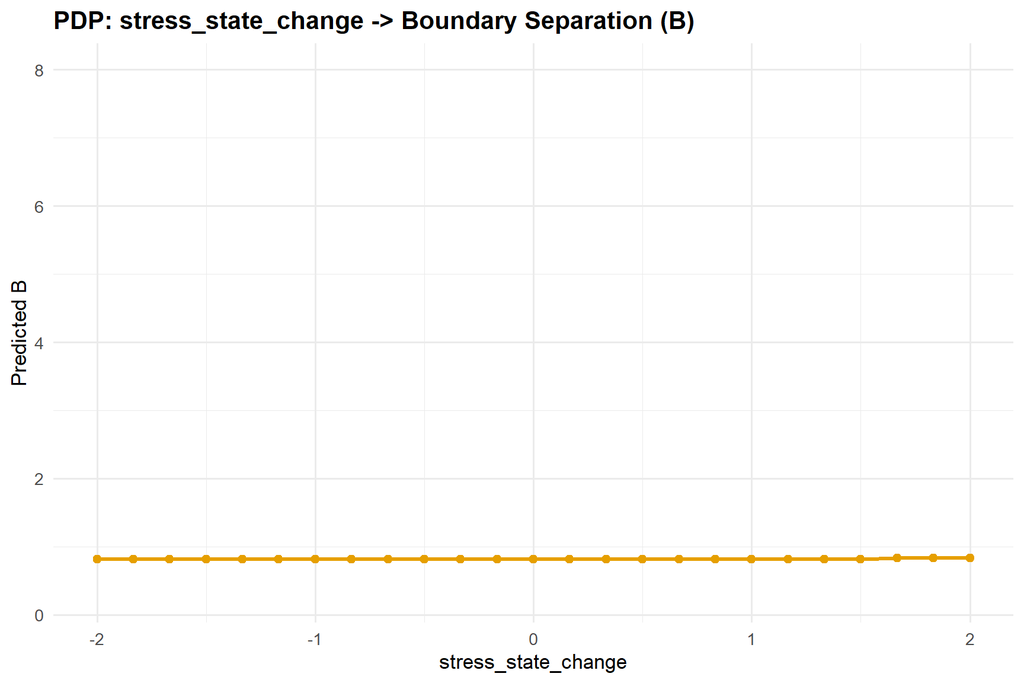

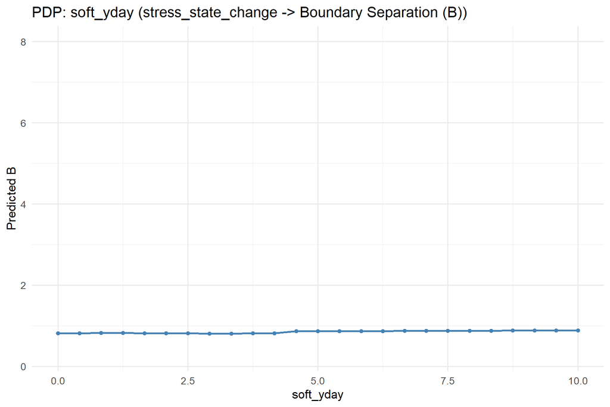

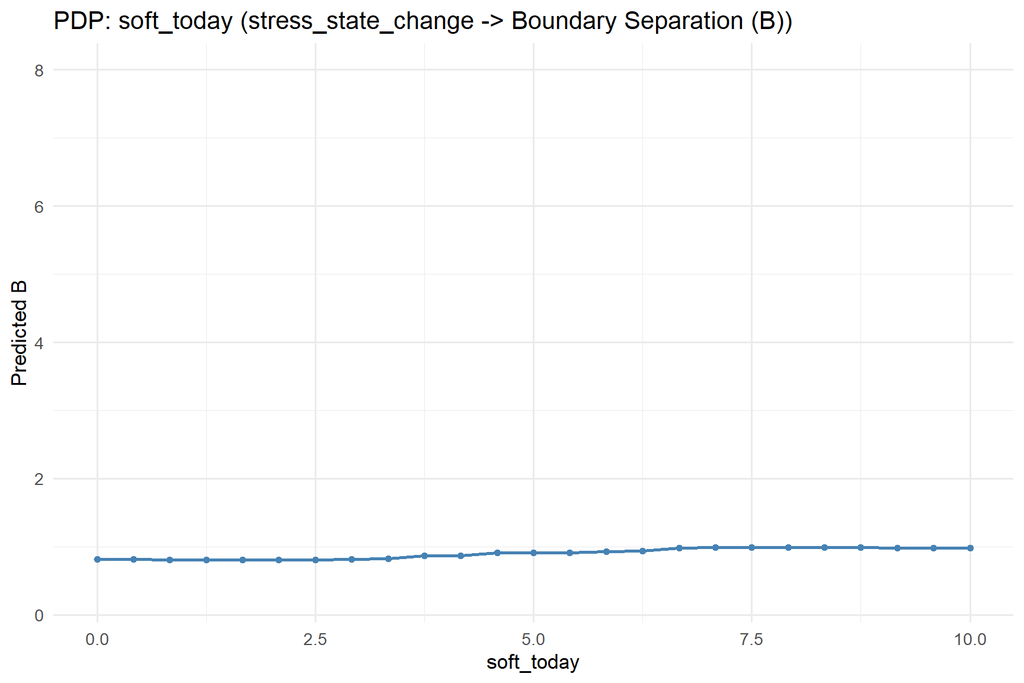

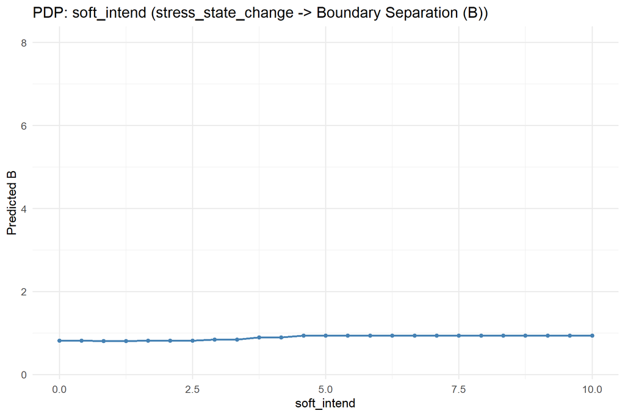

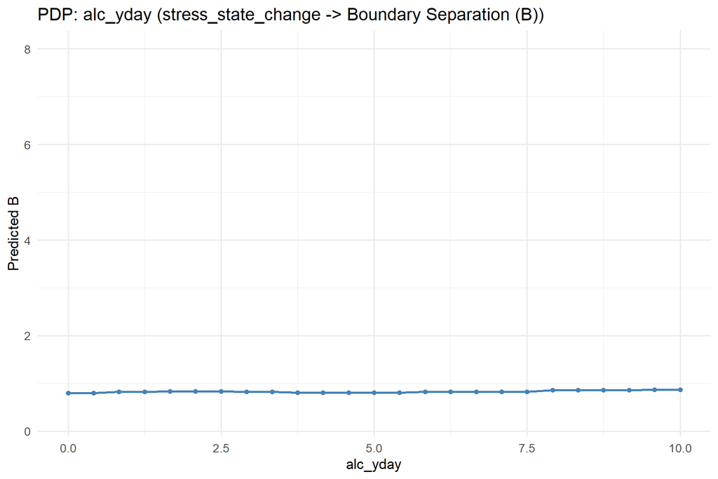

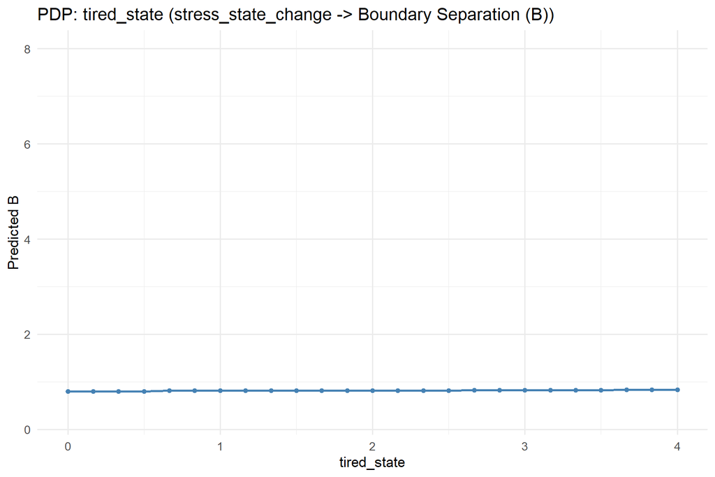

### 5.3.4 Predicted vs. Observed

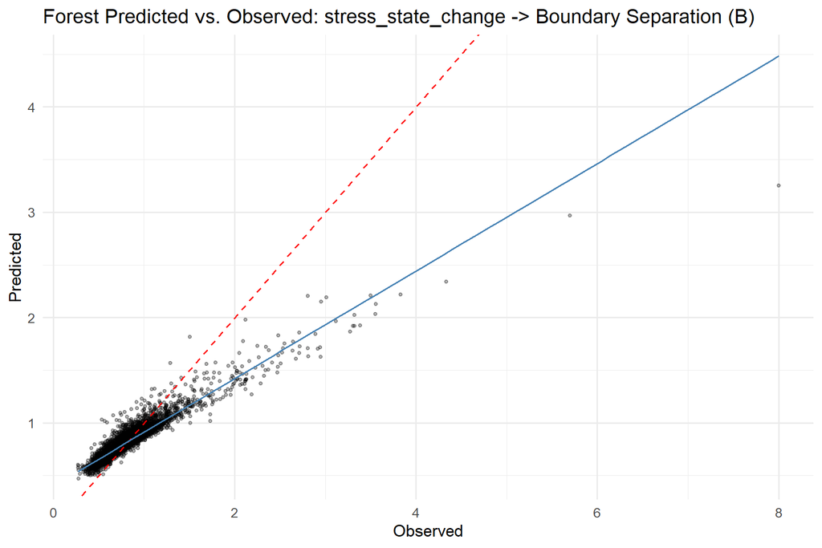

## 5.4 Model Comparison

### 5.4.1 RMSE Comparison (all methods and feature sets)

| Method | Raw | PCA | UMAP |
| --- | --- | --- | --- |
| glmm | 0.3192 | 0.3192 | 0.3193 |
| forest | 0.2926 | 0.3134 | 0.3021 |
| tree | 0.3202 | 0.3202 | 0.3197 |

# 6 Perceived Negative Affect Change (vs. last assessment) (NA_state_change)

## 6.1 Dimensionality Reduction

- **PCA components (80% variance, max 5):** 5
- **UMAP components (matching PCA):** 5

### 6.1.1 PCA Component Composition (top 5 correlated variables)

**PC_1**

| Variable | Correlation |
| --- | --- |
| alc_exp_energeticYes | -0.576 |
| alc_exp_better_moodYes | -0.557 |
| alc_exp_sociableYes | -0.547 |
| alc_exp_buzzYes | -0.503 |
| alc_craving | -0.487 |

**PC_2**

| Variable | Correlation |
| --- | --- |
| alc_exp_injuryYes | -0.596 |
| alc_exp_be_rudeYes | -0.594 |
| alc_exp_embarrassedYes | -0.579 |
| alc_exp_nauseous_vomitYes | -0.491 |
| alc_exp_hangoverYes | -0.468 |

**PC_3**

| Variable | Correlation |
| --- | --- |
| locationschool_work | 0.591 |
| alc_today | -0.578 |
| alc_cuenone | 0.569 |
| time_of_dayevening | -0.476 |
| locationhome | -0.458 |

**PC_4**

| Variable | Correlation |
| --- | --- |
| soft_yday | 0.699 |
| soft_today | 0.650 |
| soft_intend | 0.634 |
| soft_craving | 0.488 |
| alc_exp_embarrassedYes | -0.388 |

**PC_5**

| Variable | Correlation |
| --- | --- |
| locationhome | -0.632 |
| social_context_aloneYes | -0.560 |
| social_context_friend_roommateYes | 0.500 |
| social_context_strangerYes | 0.417 |
| locationsomeone_elses_home | 0.371 |

### 6.1.2 UMAP Component Composition (top 5 correlated variables)

**UMAP_1**

| Variable | Correlation |
| --- | --- |
| alc_exp_embarrassedYes | -0.300 |
| alc_exp_be_rudeYes | -0.297 |
| alc_craving | -0.223 |
| alc_intend | -0.165 |
| alc_mot_copingYes | -0.142 |

**UMAP_2**

| Variable | Correlation |
| --- | --- |
| alc_yday | 0.362 |
| alc_intend | 0.162 |
| soft_yday | -0.149 |
| alc_exp_embarrassedYes | -0.134 |
| alc_exp_be_rudeYes | -0.132 |

**UMAP_3**

| Variable | Correlation |
| --- | --- |
| alc_yday | 0.419 |
| alc_today | 0.415 |
| alc_cuenone | -0.178 |
| alc_intend | 0.169 |
| social_context_familyYes | 0.132 |

**UMAP_4**

| Variable | Correlation |
| --- | --- |
| soft_yday | -0.791 |
| soft_today | -0.676 |
| soft_intend | -0.566 |
| soft_craving | -0.305 |
| alc_exp_be_rudeYes | -0.192 |

**UMAP_5**

| Variable | Correlation |
| --- | --- |
| alc_exp_injuryYes | -0.511 |
| alc_exp_embarrassedYes | -0.383 |
| alc_exp_be_rudeYes | -0.380 |
| alc_exp_nauseous_vomitYes | -0.354 |
| alc_exp_energeticYes | -0.231 |

## 6.2 GLMM Results

### 6.2.1 Raw Features

- **Optimal lambda:** 170 (index 4 of 21)
- **CV RMSE:** 0.3164

**Non-zero coefficients** (focal predictor terms highlighted):

| Term | Estimate | Category |
| --- | --- | --- |
| (Intercept) | 0.8231 | Intercept |
| NA_state_change | -0.0086 | Focal predictor |
| alc_craving | -0.0198 | Covariate main effect |
| time_of_dayevening:NA_state_change | 0.0509 | Interaction with focal predictor |
| locationhome:NA_state_change | -0.0107 | Interaction with focal predictor |
| alc_today:NA_state_change | -0.0043 | Interaction with focal predictor |
| responsibilityYes:NA_state_change | -0.0033 | Interaction with focal predictor |
| tired_state:NA_state_change | -0.0029 | Interaction with focal predictor |
| alc_mot_copingYes:NA_state_change | 0.0026 | Interaction with focal predictor |
| alc_cuenone:NA_state_change | 0.0020 | Interaction with focal predictor |
| alc_exp_relaxedYes:NA_state_change | -0.0012 | Interaction with focal predictor |
| social_context_aloneYes:NA_state_change | 0.0010 | Interaction with focal predictor |
| soft_yday:NA_state_change | 0.0007 | Interaction with focal predictor |
| soft_today:NA_state_change | -0.0007 | Interaction with focal predictor |
| alc_craving:NA_state_change | -0.0007 | Interaction with focal predictor |
| thirst_state:NA_state_change | 0.0006 | Interaction with focal predictor |
| alc_yday:NA_state_change | -0.0001 | Interaction with focal predictor |
| alc_mot_enhanceYes:NA_state_change | 0.0001 | Interaction with focal predictor |

- 80 coefficients penalized to zero.*

#### 6.2.1.1 Predicted vs. Observed

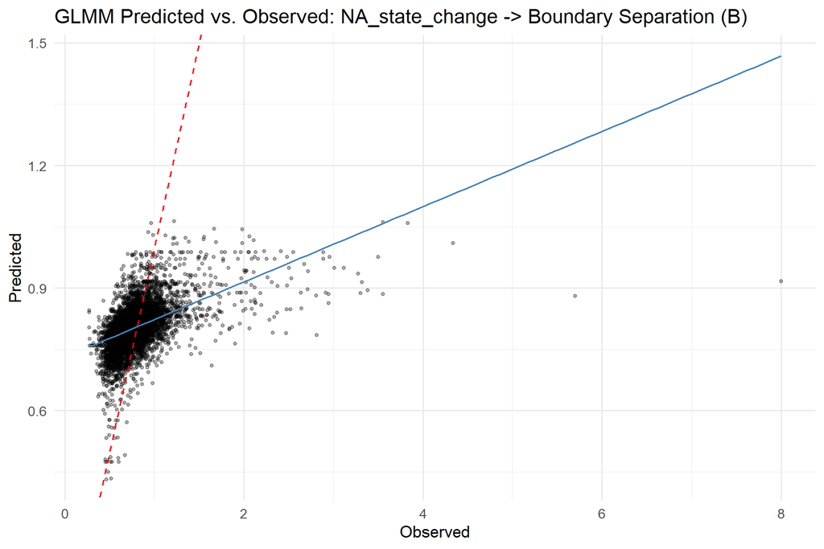

#### 6.2.1.2 Residual Diagnostics

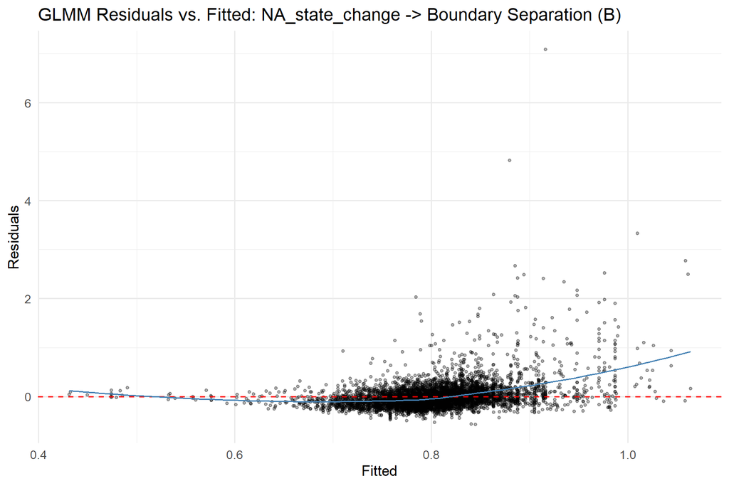

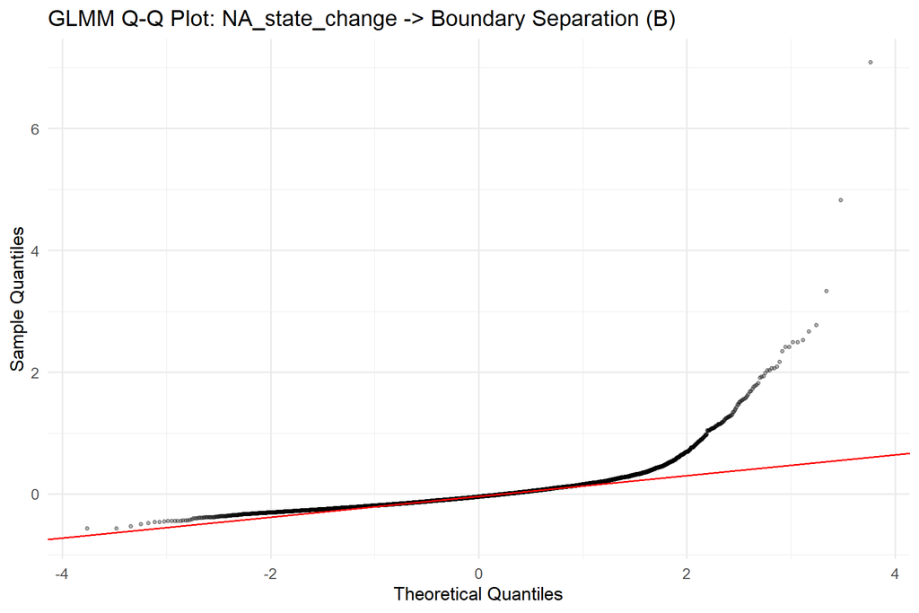

### 6.2.2 PCA Features

- **Optimal lambda:** 140 (index 7 of 21)
- **CV RMSE:** 0.3167

**Non-zero coefficients:**

| Term | Estimate |
| --- | --- |
| (Intercept) | 0.8083 |
| PC_2 | -0.0175 |
| PC_5:NA_state_change | 0.0070 |

- 9 coefficients penalized to zero.*

### 6.2.3 UMAP Features

- **Optimal lambda:** 190 (index 2 of 21)
- **CV RMSE:** 0.3167

**Non-zero coefficients:**

| Term | Estimate |
| --- | --- |
| (Intercept) | 0.8065 |
| UMAP_5:NA_state_change | -0.0050 |

- 10 coefficients penalized to zero.*

## 6.3 Random Forest Results (Raw)

### 6.3.1 Tuning Summary

- **mtry:** 14
- **min.node.size:** 6
- **sample.fraction:** 0.782
- **CV RMSE:** 0.2913

### 6.3.2 Variable Importance (Permutation)

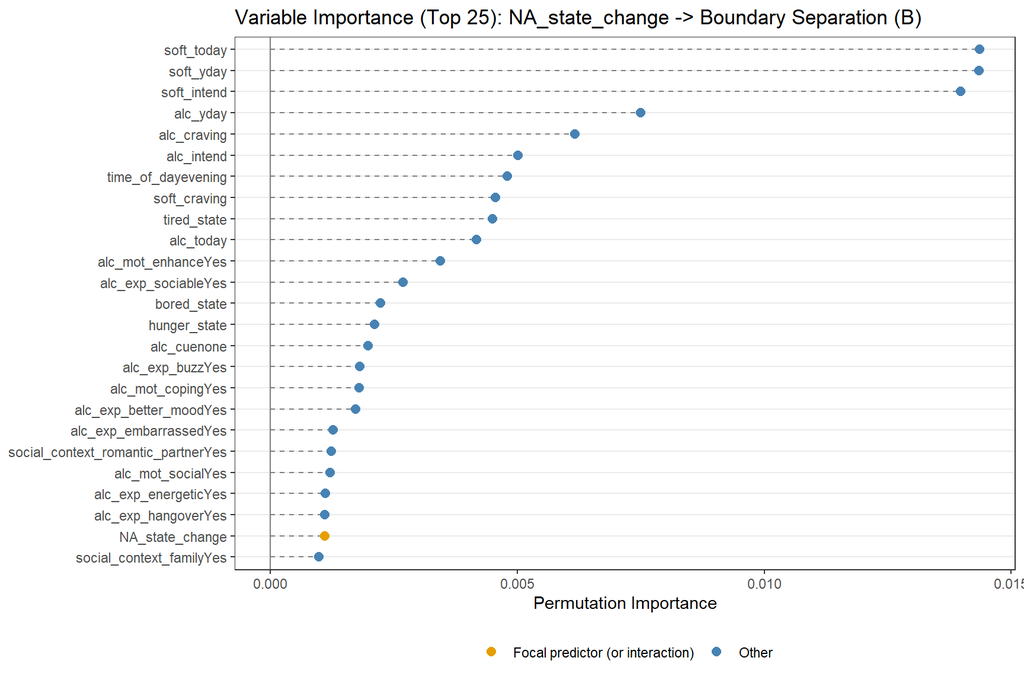

**Full importance ranking:**

| Variable | Importance |
| --- | --- |
| soft_today | 0.014361 |
| soft_yday | 0.014343 |
| soft_intend | 0.013981 |
| alc_yday | 0.007492 |
| alc_craving | 0.006165 |
| alc_intend | 0.005010 |
| time_of_dayevening | 0.004800 |
| soft_craving | 0.004561 |
| tired_state | 0.004496 |
| alc_today | 0.004176 |
| alc_mot_enhanceYes | 0.003441 |
| alc_exp_sociableYes | 0.002686 |
| bored_state | 0.002225 |
| hunger_state | 0.002112 |
| alc_cuenone | 0.001983 |
| alc_exp_buzzYes | 0.001810 |
| alc_mot_copingYes | 0.001801 |
| alc_exp_better_moodYes | 0.001723 |
| alc_exp_embarrassedYes | 0.001265 |
| social_context_romantic_partnerYes | 0.001239 |
| alc_mot_socialYes | 0.001208 |
| alc_exp_energeticYes | 0.001118 |
| alc_exp_hangoverYes | 0.001108 |
| NA_state_change | 0.001107 |
| social_context_familyYes | 0.000987 |
| thirst_state | 0.000927 |
| alc_exp_be_rudeYes | 0.000870 |
| social_context_aloneYes | 0.000740 |
| locationhome | 0.000697 |
| responsibilityYes | 0.000599 |
| alc_exp_nauseous_vomitYes | 0.000342 |
| locationschool_work | 0.000342 |
| day_of_weekMon | 0.000212 |
| social_context_coworker_classmateYes | 0.000119 |
| social_context_friend_roommateYes | 0.000111 |
| alc_exp_relaxedYes | 0.000065 |
| alc_exp_injuryYes | 0.000050 |
| alc_cueindirectly_visible | 0.000049 |
| locationsomeone_elses_home | 0.000018 |
| social_context_otherYes | 0.000007 |
| locationrestaurant_cafe | 0.000004 |
| locationoutdoors | -0.000008 |
| social_context_strangerYes | -0.000041 |
| day_of_weekTue | -0.000076 |
| locationother | -0.000089 |
| day_of_weekThu | -0.000117 |
| day_of_weekSun | -0.000382 |
| day_of_weekWed | -0.000403 |
| day_of_weekSat | -0.001704 |

### 6.3.3 Partial Dependence Plots

PDP for the focal predictor and the top 5 most important non-interaction covariates.

#### 6.3.3.1 Focal Predictor: NA_state_change

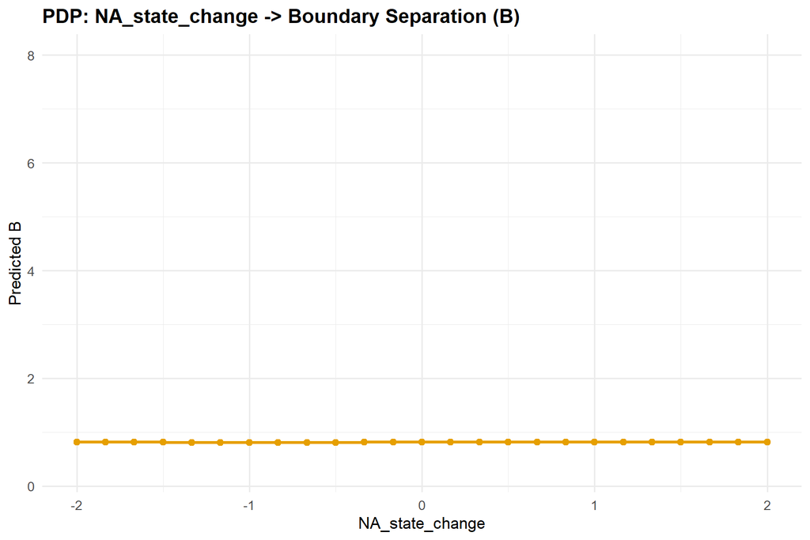

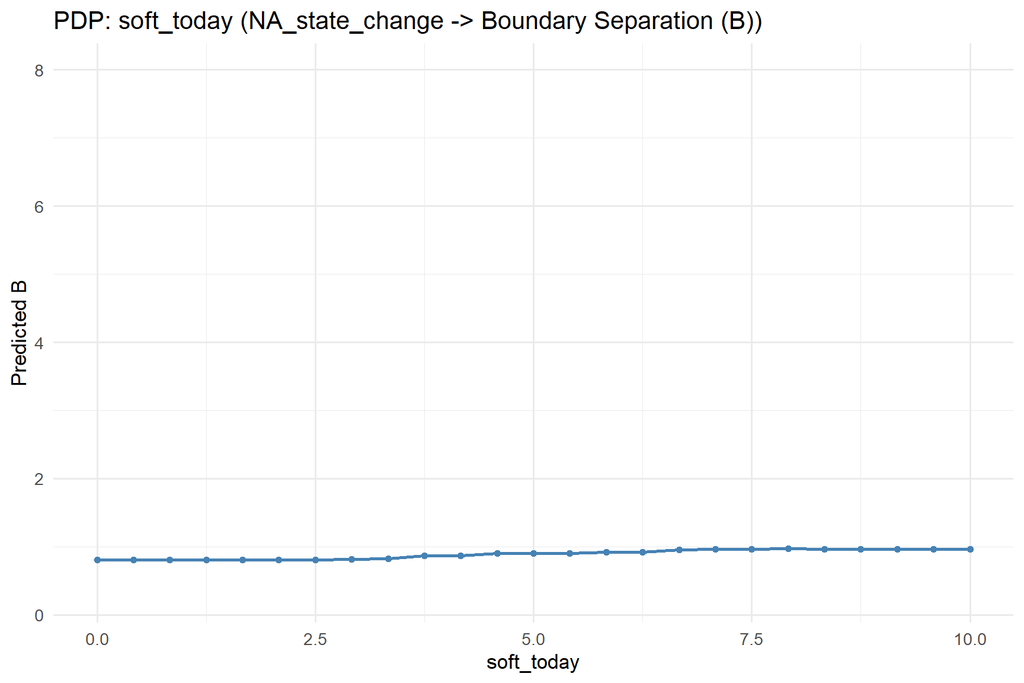

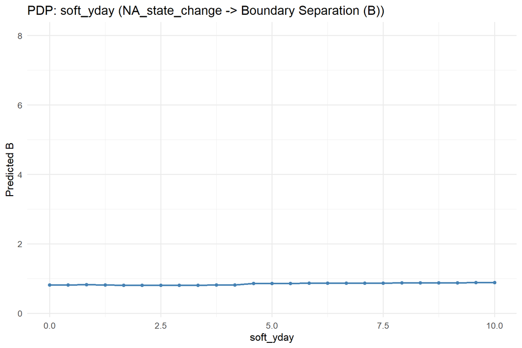

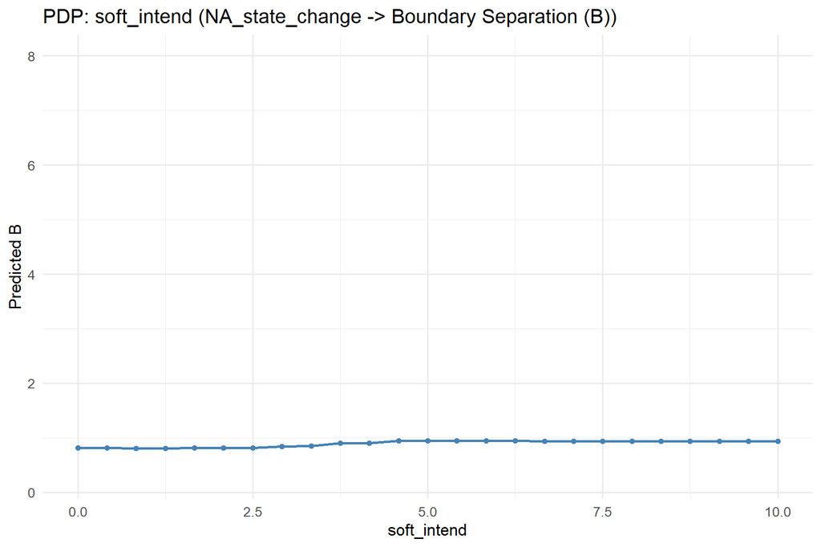

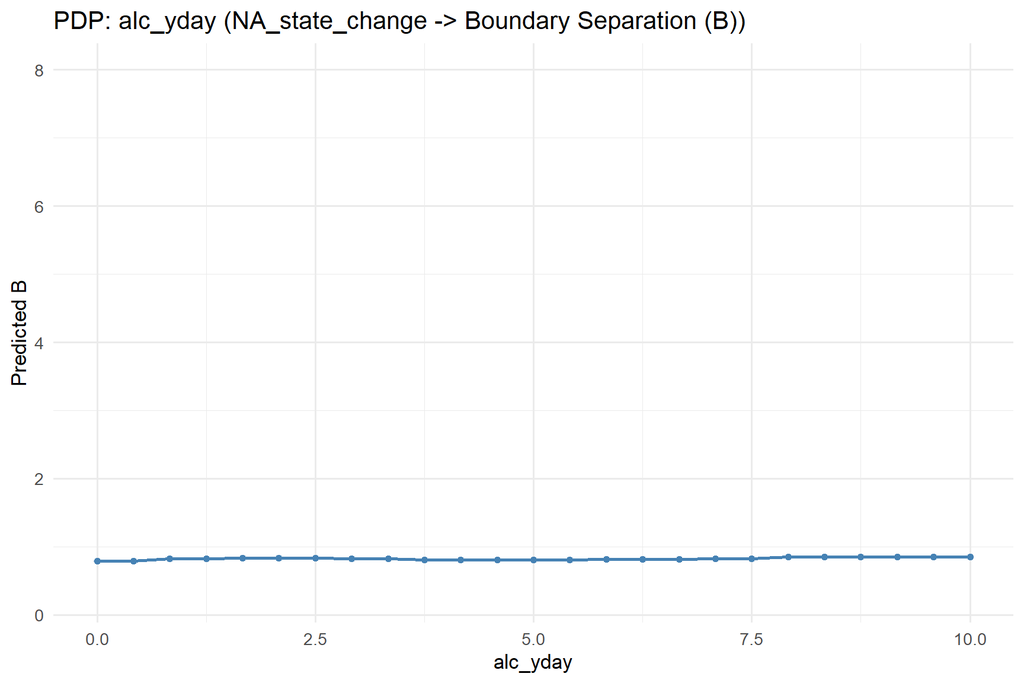

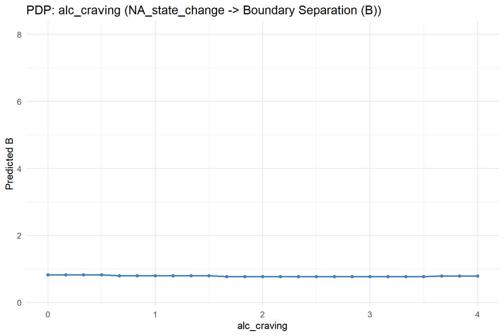

### 6.3.4 Predicted vs. Observed

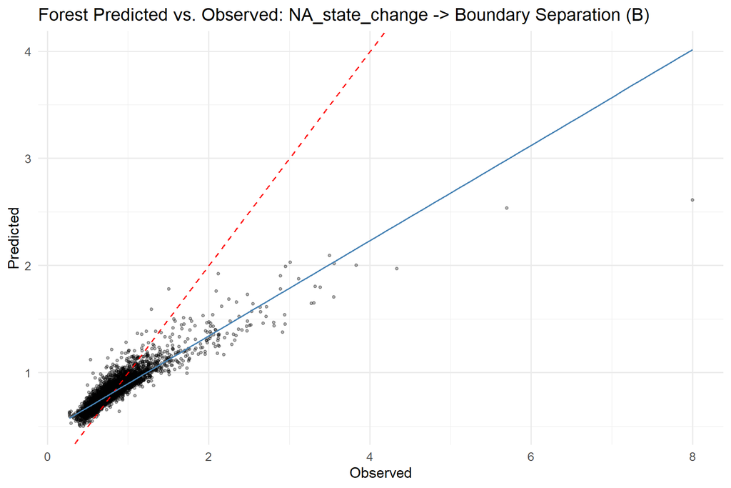

## 6.4 Model Comparison

### 6.4.1 RMSE Comparison (all methods and feature sets)

| Method | Raw | PCA | UMAP |
| --- | --- | --- | --- |
| glmm | 0.3164 | 0.3167 | 0.3167 |
| forest | 0.2913 | 0.3104 | 0.2989 |
| tree | 0.3178 | 0.3173 | 0.3142 |

# 7 Perceived Positive Affect Change (vs. last assessment) (PA_state_change)

## 7.1 Dimensionality Reduction

- **PCA components (80% variance, max 5):** 5
- **UMAP components (matching PCA):** 5

### 7.1.1 PCA Component Composition (top 5 correlated variables)

**PC_1**

| Variable | Correlation |
| --- | --- |
| alc_exp_energeticYes | -0.576 |
| alc_exp_better_moodYes | -0.557 |
| alc_exp_sociableYes | -0.547 |
| alc_exp_buzzYes | -0.502 |
| alc_craving | -0.487 |

**PC_2**

| Variable | Correlation |
| --- | --- |
| alc_exp_injuryYes | -0.595 |
| alc_exp_be_rudeYes | -0.593 |
| alc_exp_embarrassedYes | -0.578 |
| alc_exp_nauseous_vomitYes | -0.491 |
| alc_exp_hangoverYes | -0.468 |

**PC_3**

| Variable | Correlation |
| --- | --- |
| locationschool_work | 0.590 |
| alc_today | -0.578 |
| alc_cuenone | 0.568 |
| time_of_dayevening | -0.476 |
| locationhome | -0.457 |

**PC_4**

| Variable | Correlation |
| --- | --- |
| soft_yday | 0.699 |
| soft_today | 0.650 |
| soft_intend | 0.633 |
| soft_craving | 0.488 |
| alc_exp_embarrassedYes | -0.389 |

**PC_5**

| Variable | Correlation |
| --- | --- |
| locationhome | -0.633 |
| social_context_aloneYes | -0.560 |
| social_context_friend_roommateYes | 0.500 |
| social_context_strangerYes | 0.417 |
| locationsomeone_elses_home | 0.371 |

### 7.1.2 UMAP Component Composition (top 5 correlated variables)

**UMAP_1**

| Variable | Correlation |
| --- | --- |
| alc_exp_embarrassedYes | -0.314 |
| alc_exp_be_rudeYes | -0.311 |
| alc_craving | -0.295 |
| alc_intend | -0.232 |
| alc_mot_copingYes | -0.176 |

**UMAP_2**

| Variable | Correlation |
| --- | --- |
| alc_yday | 0.321 |
| alc_intend | 0.137 |
| soft_yday | -0.135 |
| alc_exp_embarrassedYes | -0.120 |
| alc_mot_enhanceYes | 0.119 |

**UMAP_3**

| Variable | Correlation |
| --- | --- |
| alc_yday | 0.378 |
| alc_today | 0.359 |
| thirst_state | -0.146 |
| alc_cuenone | -0.140 |
| soft_craving | -0.139 |

**UMAP_4**

| Variable | Correlation |
| --- | --- |
| soft_yday | -0.793 |
| soft_today | -0.673 |
| soft_intend | -0.568 |
| soft_craving | -0.309 |
| alc_exp_be_rudeYes | -0.178 |

**UMAP_5**

| Variable | Correlation |
| --- | --- |
| alc_exp_injuryYes | 0.506 |
| alc_exp_embarrassedYes | 0.357 |
| alc_exp_nauseous_vomitYes | 0.356 |
| alc_exp_be_rudeYes | 0.355 |
| alc_exp_energeticYes | 0.203 |

## 7.2 GLMM Results

### 7.2.1 Raw Features

- **Optimal lambda:** 180 (index 3 of 21)
- **CV RMSE:** 0.3163

**Non-zero coefficients** (focal predictor terms highlighted):

| Term | Estimate | Category |
| --- | --- | --- |
| (Intercept) | 0.8067 | Intercept |
| PA_state_change | 0.0074 | Focal predictor |
| alc_craving | -0.0013 | Covariate main effect |
| time_of_dayevening:PA_state_change | -0.0387 | Interaction with focal predictor |
| locationhome:PA_state_change | 0.0089 | Interaction with focal predictor |
| tired_state:PA_state_change | 0.0032 | Interaction with focal predictor |
| responsibilityYes:PA_state_change | 0.0025 | Interaction with focal predictor |
| alc_cuenone:PA_state_change | 0.0019 | Interaction with focal predictor |
| alc_today:PA_state_change | 0.0010 | Interaction with focal predictor |
| soft_today:PA_state_change | 0.0005 | Interaction with focal predictor |
| social_context_aloneYes:PA_state_change | -0.0005 | Interaction with focal predictor |
| alc_craving:PA_state_change | -0.0003 | Interaction with focal predictor |
| alc_exp_relaxedYes:PA_state_change | 0.0001 | Interaction with focal predictor |

- 85 coefficients penalized to zero.*

#### 7.2.1.1 Predicted vs. Observed

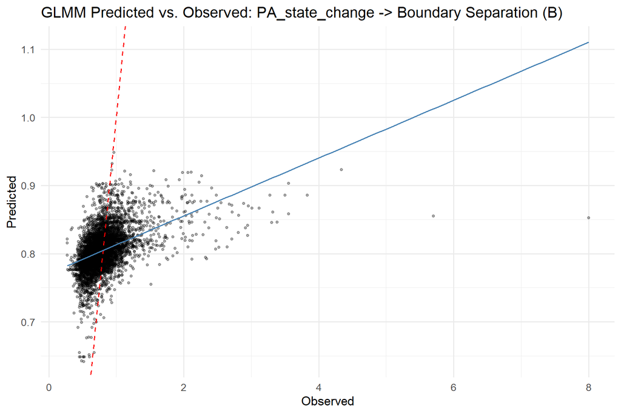

#### 7.2.1.2 Residual Diagnostics

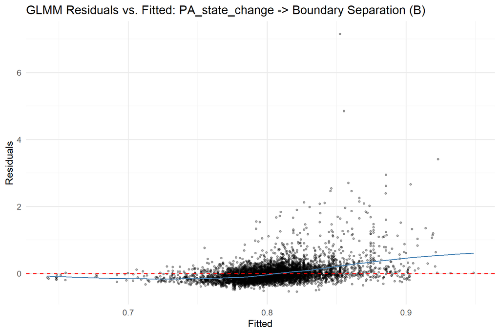

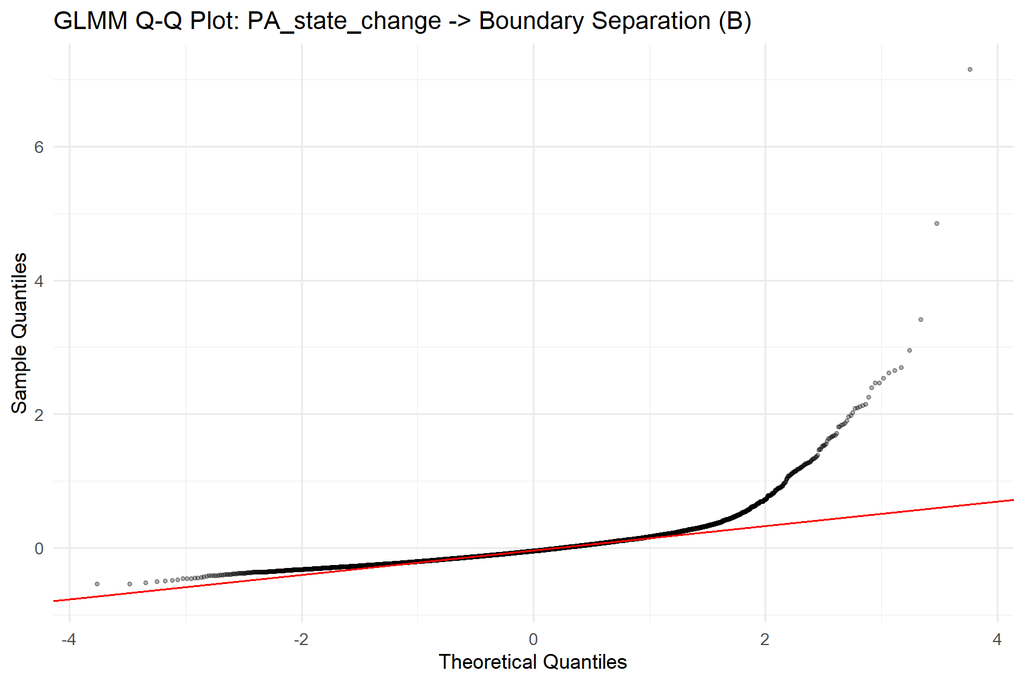

### 7.2.2 PCA Features

- **Optimal lambda:** 130 (index 8 of 21)
- **CV RMSE:** 0.3161

**Non-zero coefficients:**

| Term | Estimate |
| --- | --- |
| (Intercept) | 0.8060 |
| PC_5:PA_state_change | -0.0042 |

- 10 coefficients penalized to zero.*

### 7.2.3 UMAP Features

- **Optimal lambda:** 60 (index 15 of 21)
- **CV RMSE:** 0.3162

**Non-zero coefficients:**

| Term | Estimate |
| --- | --- |
| (Intercept) | 0.8054 |
| UMAP_1 | -0.0155 |
| UMAP_4 | -0.0190 |
| UMAP_1:PA_state_change | 0.0050 |
| UMAP_5:PA_state_change | -0.0111 |

- 7 coefficients penalized to zero.*

## 7.3 Random Forest Results (Raw)

### 7.3.1 Tuning Summary

- **mtry:** 13
- **min.node.size:** 4
- **sample.fraction:** 0.752
- **CV RMSE:** 0.2909

### 7.3.2 Variable Importance (Permutation)

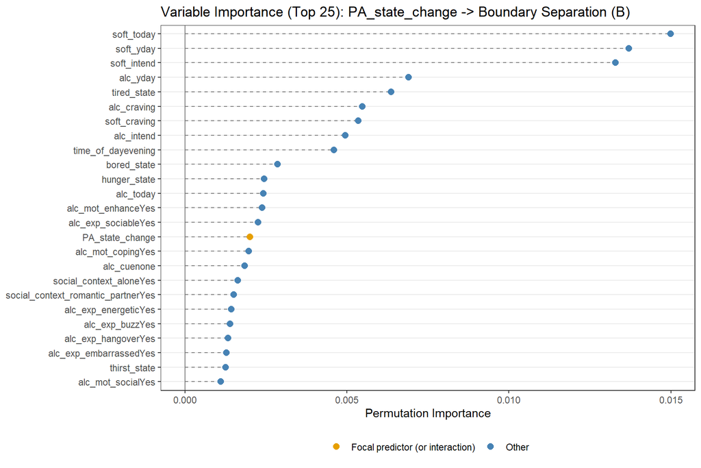

**Full importance ranking:**

| Variable | Importance |
| --- | --- |
| soft_today | 0.014993 |
| soft_yday | 0.013696 |
| soft_intend | 0.013292 |
| alc_yday | 0.006903 |
| tired_state | 0.006367 |
| alc_craving | 0.005471 |
| soft_craving | 0.005343 |
| alc_intend | 0.004949 |
| time_of_dayevening | 0.004593 |
| bored_state | 0.002858 |
| hunger_state | 0.002436 |
| alc_today | 0.002419 |
| alc_mot_enhanceYes | 0.002377 |
| alc_exp_sociableYes | 0.002253 |
| PA_state_change | 0.002000 |
| alc_mot_copingYes | 0.001968 |
| alc_cuenone | 0.001842 |
| social_context_aloneYes | 0.001621 |
| social_context_romantic_partnerYes | 0.001505 |
| alc_exp_energeticYes | 0.001420 |
| alc_exp_buzzYes | 0.001390 |
| alc_exp_hangoverYes | 0.001332 |
| alc_exp_embarrassedYes | 0.001271 |
| thirst_state | 0.001256 |
| alc_mot_socialYes | 0.001097 |
| alc_exp_better_moodYes | 0.001015 |
| locationhome | 0.000954 |
| alc_exp_be_rudeYes | 0.000747 |
| alc_exp_relaxedYes | 0.000571 |
| social_context_familyYes | 0.000412 |
| responsibilityYes | 0.000362 |
| alc_exp_nauseous_vomitYes | 0.000332 |
| locationschool_work | 0.000272 |
| social_context_friend_roommateYes | 0.000190 |
| day_of_weekMon | 0.000149 |
| social_context_coworker_classmateYes | 0.000118 |
| alc_exp_injuryYes | 0.000050 |
| locationoutdoors | 0.000044 |
| social_context_otherYes | 0.000012 |
| locationrestaurant_cafe | 0.000010 |
| alc_cueindirectly_visible | 0.000003 |
| social_context_strangerYes | 0.000001 |
| locationsomeone_elses_home | -0.000021 |
| locationother | -0.000027 |
| day_of_weekSun | -0.000215 |
| day_of_weekThu | -0.000289 |
| day_of_weekTue | -0.000381 |
| day_of_weekWed | -0.000409 |
| day_of_weekSat | -0.000920 |

### 7.3.3 Partial Dependence Plots

PDP for the focal predictor and the top 5 most important non-interaction covariates.

#### 7.3.3.1 Focal Predictor: PA_state_change

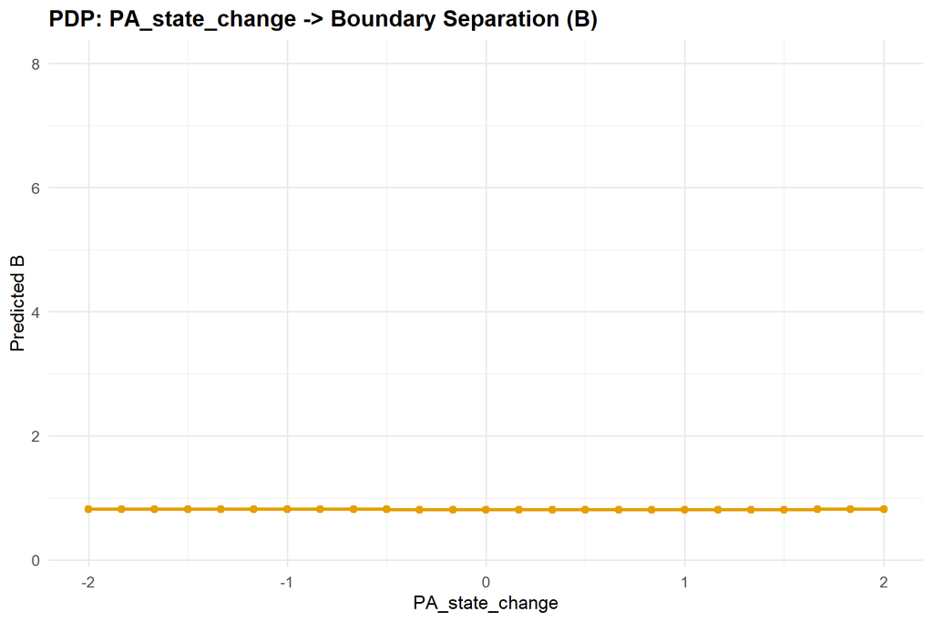

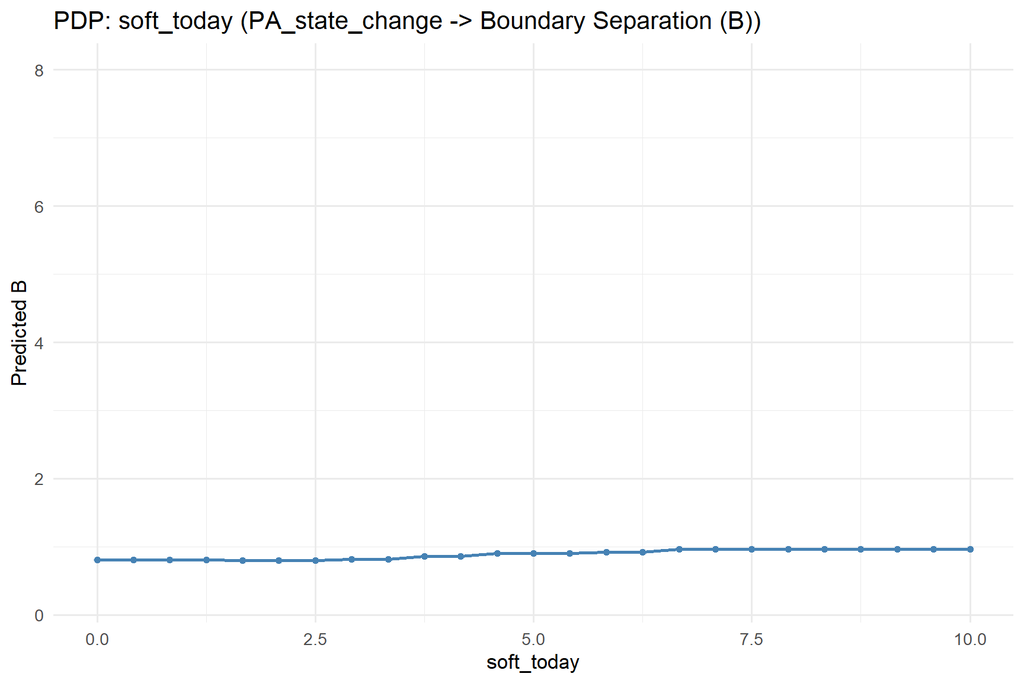

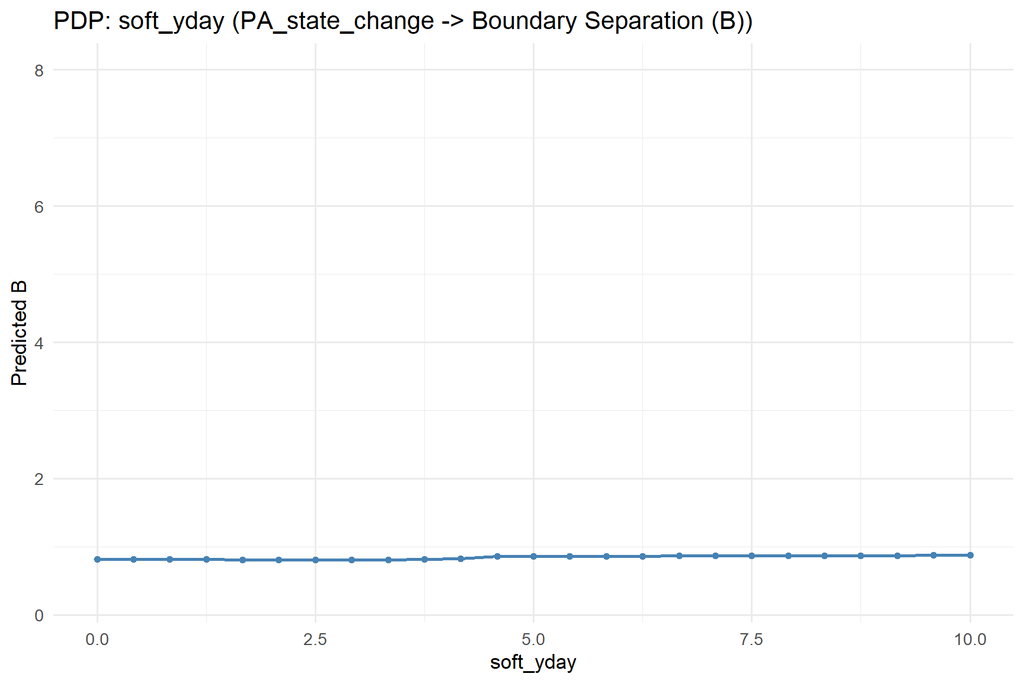

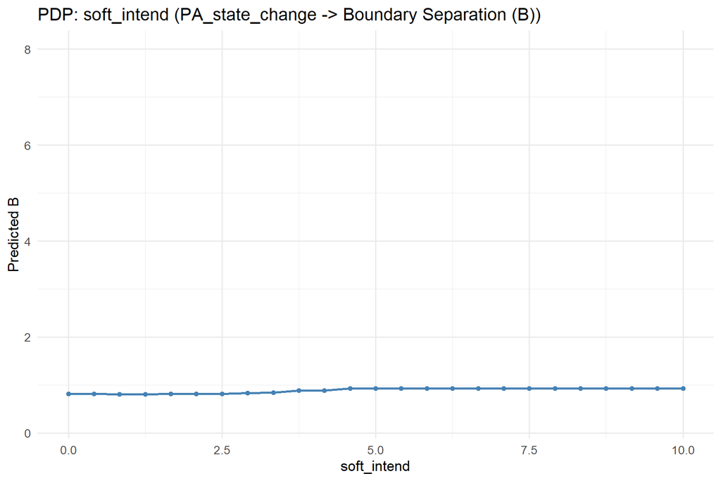

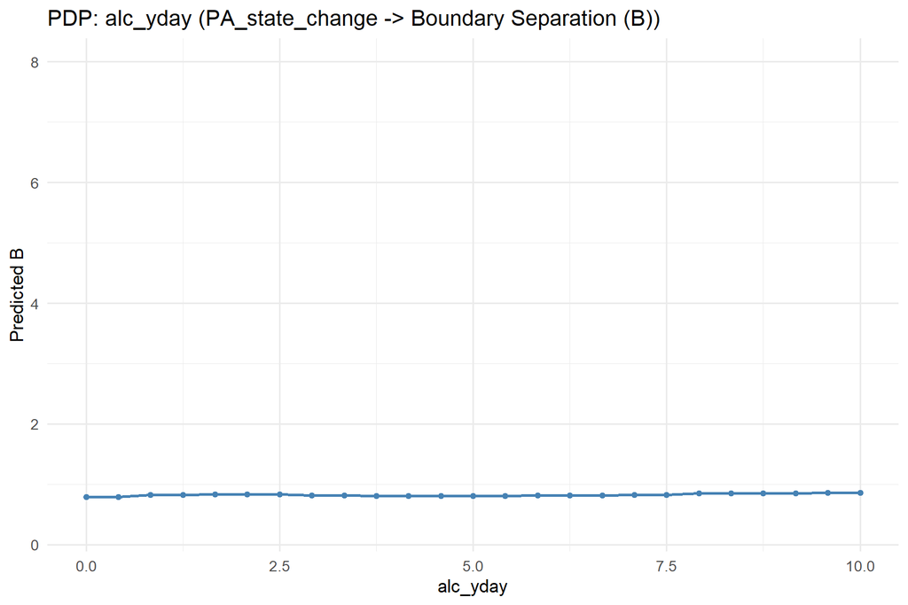

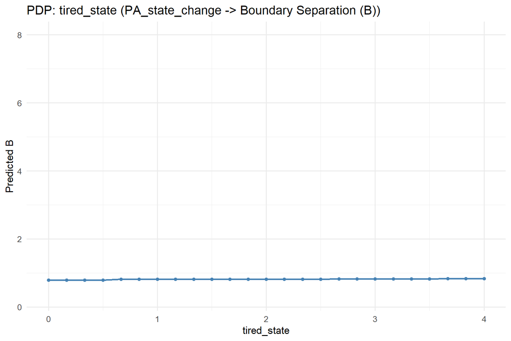

### 7.3.4 Predicted vs. Observed

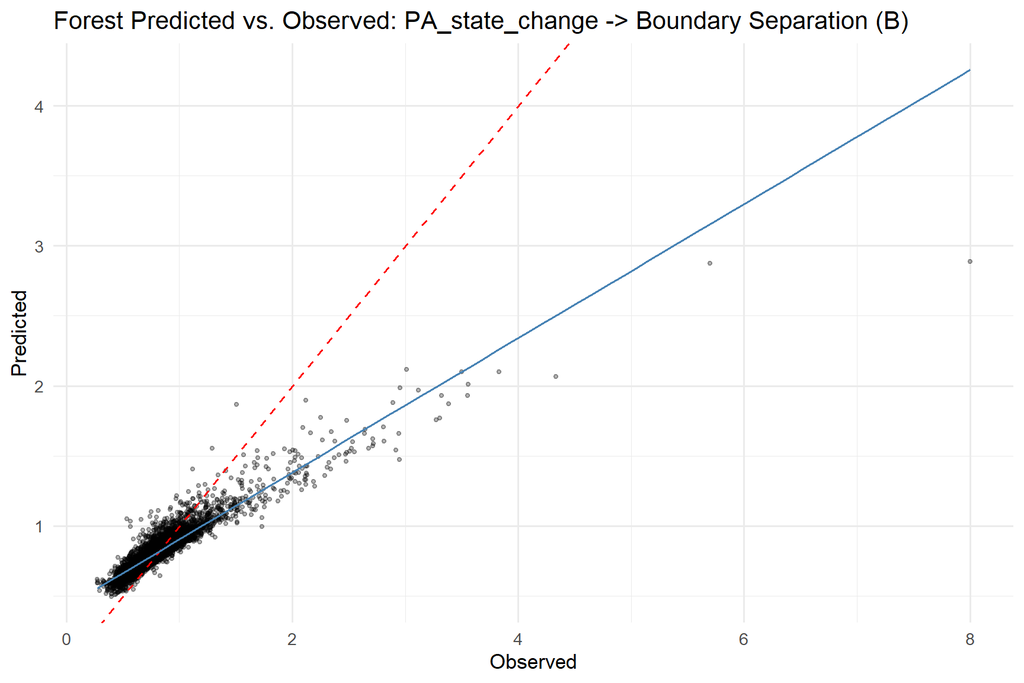

## 7.4 Model Comparison

### 7.4.1 RMSE Comparison (all methods and feature sets)

| Method | Raw | PCA | UMAP |
| --- | --- | --- | --- |
| glmm | 0.3163 | 0.3161 | 0.3162 |
| forest | 0.2909 | 0.3097 | 0.2986 |
| tree | 0.3173 | 0.3173 | 0.3173 |